# HUDM5124Assignment9

Zhuqian Zhou

2017/3/27

## Step 1 Run K-mean Cluster

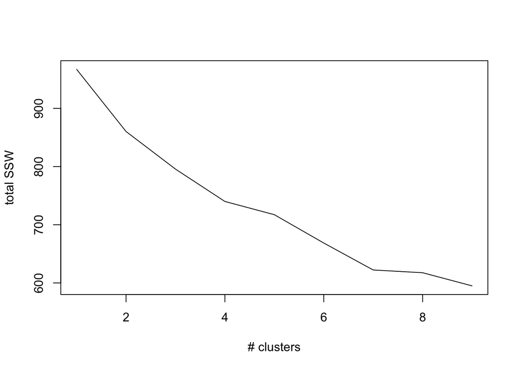

```r
csna <- read.csv("CSNA_MLT.csv", sep = ",", header = TRUE)
x <- csna[,4:17] # select 14 binary vairables
WSSvector <- c(0,0,0,0,0,0,0,0,0)
for (i in 1:9)
{ cl <- kmeans(x, i)
WSSvector[i] <- cl$tot.withinss
} # partition the data set into 1-9 clusters and record total within SS for each solution
plot(WSSvector,type="l",xlab="# clusters",ylab="total SSW") # plot the total within-cluster sum of squares against the number of clusters
```

I use default cluster seeds, i.e. random seeds – randomly select a set of n points as a first guess of the means of the clusters.

There seems to be no anomalies in the plot. The total SSW decreases gradually from 1 to 9 clusters indicating the increase of the accuracy of clustering when the number of clusters goes higher.

## Step 2

The line plot above shows evidence for 5-9 clusters. I will choose 6 as the optimal number of clusters.

```r
cl6 <- kmeans(x, 6) # re-run the optimal solution
csna$cl6 <- cl6$cluster # save the cluster membership of each case as a new varibale in the data frame csna
csna$cl6
```

```
##   [1] 2 4 6 1 1 2 6 5 2 4 1 3 3 3 2 5 4 3 1 5 4 4 5 3 3 1 1 5 2 3 4 2 3 1 3
##  [36] 5 3 1 2 5 4 5 2 3 5 5 3 2 3 6 6 2 2 3 5 6 4 1 5 5 1 1 2 1 6 2 1 5 1 3
##  [71] 2 2 3 2 5 1 4 5 3 4 5 2 5 4 2 6 5 6 2 1 4 5 3 2 2 1 4 4 6 3 3 6 3 3 2
## [106] 1 2 5 3 5 1 1 5 4 2 6 5 6 5 2 1 6 5 2 2 3 1 5 3 3 4 2 2 3 2 5 2 1 2 3
## [141] 3 2 4 1 3 2 5 4 5 3 2 2 5 5 2 2 3 1 2 4 2 2 4 2 3 1 5 1 6 5 2 2 2 2 2
## [176] 4 5 3 3 2 3 3 2 6 4 6 4 1 3 5 4 3 1 6 4 4 5 2 3 2 2 3 2 6 1 2 5 1 5 5
## [211] 2 2 1 4 4 1 2 2 6 1 5 2 3 4 5 3 5 4 3 6 6 5 4 2 2 2 5 5 5 6 2 2 5 2 1
## [246] 3 1 5 5 4 3 6 6 5 4 2 2 2 5 5 5 6 2 2 5 2 1 3 1 3 2 2 6 2 2 4 5 5 4 5
## [281] 3 2 5 3 5 2 4 2 2 6 4 5 6 3 6 2 5 3 5 1 2 3 2 5 2 6 1 2 2 6 5 4 6 3 2
## [316] 4 3 5 4 4 5 6 6 6 6 1 5 3 4 2 5 2 3 2 5 2 3 3 2 5 2 3 3 6 6 2 6 2 6 3
## [351] 2 1 5 5 2 6 2 3 6 3 3 3 3 2 3 5 6 1 3 4 1 4 2 3 5 3 6 6 2 1 4 2 3 1 2
## [386] 5 3 5 5 3 5 3 1 2 3 2 1 6 1 5 1 6 2 3 1 2 3
```